# Sampling and Probability

郭耀仁 Yao-Jen Kuo

# The measure of chances

## The definition of probability

$$P(Event) = \frac{\text{Number of ways event can happen}}{\text{Total number of ways event can happen}}$$

## Flipping a coin

```r
coin <- c("Head", "Tail")
sample(coin, size = 1, replace = TRUE)
```

```
## [1] "Tail"
```

## Rolling a dice for 2 times

```r
dice <- 1:6
sample(dice, size = 2, replace = TRUE)
```

```
## [1] 1 2
```

## The `replace` argument

- `replace = TRUE` refers to independent events
- `replace = FALSE` refers to dependent events

## Independent vs. dependent events

- Events are independent if the probability of the latter isn’t affected by the outcome of the previous, e.g. flipping coin and rolling dice
- Events are dependent if the probability of the latter is affected by the outcome of the previous, e.g. dealing cards

## Dealing poker cards

```r
generate_poker_deck <- function() {
  suits <- c("Spades", "Hearts", "Diamonds", "Clubs")
  ranks <- c("Ace", 2:10, "Jack", "Queen", "King")
  poker_deck <- c()
  for (s in suits) {
    for (r in ranks) {
      card <- sprintf("%s of %s", r, s)
      poker_deck <- c(poker_deck, card)
    }
  }
  return(poker_deck)
}
poker_deck <- generate_poker_deck()
sample(poker_deck, size = 13, replace = FALSE)
```

```
##  [1] "Queen of Spades"  "9 of Spades"      "10 of Clubs"      "Ace of Hearts"
##  [5] "Queen of Hearts"  "7 of Hearts"      "King of Diamonds" "5 of Hearts"
##  [9] "Jack of Hearts"   "King of Spades"   "8 of Hearts"      "7 of Clubs"
## [13] "4 of Clubs"
```

# Binomial distribution

## Flipping `size` coin(s) for `n` time(s) with built-in function `rbinom()`

```r
rbinom(n = 1, size = 1, prob = 0.5)  # single flip, single time
```

```
## [1] 0
```

```r
rbinom(n = 3, size = 1, prob = 0.5)  # single flip, many times
```

```
## [1] 0 1 1
```

```r
rbinom(n = 1, size = 3, prob = 0.5)  # many flips, single time
```

```
## [1] 1
```

```r
rbinom(n = 20, size = 3, prob = 0.5) # many flips, many times
```

```
##  [1] 1 1 0 2 2 0 2 0 2 1 2 1 3 2 2 3 2 1 0 1
```

## Other associated built-in functions for binomial distribution

- `dbinom()`
- `pbinom()`

## `dbinom()` function measures the probability of getting `x` successes out of `size` trials

```r
dbinom(x = 0, size = 10, prob = 0.5) # the probability of getting 0 head out of 10 times of single flip
```

```
## [1] 0.0009765625
```

```r
dbinom(x = 1, size = 10, prob = 0.5) # the probability of getting 1 head out of 10 times of single flip
```

```
## [1] 0.009765625
```

```r
dbinom(x = 2, size = 10, prob = 0.5) # the probability of getting 2 heads out of 10 times of single flip
```

```
## [1] 0.04394531
```

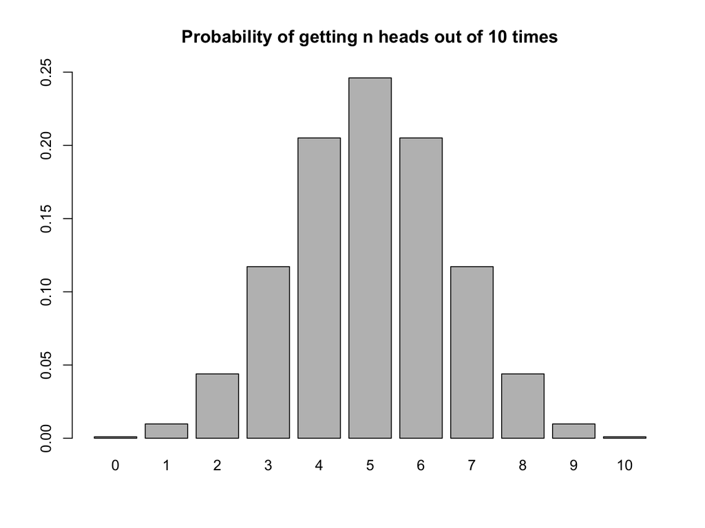

```r
n_head <- 0:10
n_head_probs <- dbinom(x = n_head, size = 10, prob = 0.5)
barplot(n_head_probs, names.arg = n_head, ylim = c(0, 0.25), main = "Probability of getting n heads out of 10 times")
```

## `pbinom()` function measures the probability of getting less than or equal to `x` successes out of `size` trials

```r
pbinom(q = 0, size = 10, prob = 0.5) # the probability of getting less than or equal to 0 head out of 10 times of trials
```

```
## [1] 0.0009765625
```

```r
pbinom(q = 1, size = 10, prob = 0.5) # the probability of getting less than or equal to 0 head out of 10 times of trials
```

```
## [1] 0.01074219
```

```r
dbinom(x = 0, size = 10, prob = 0.5) + dbinom(x = 1, size = 10, prob = 0.5)
```

```
## [1] 0.01074219
```

## What if we want to measure the probability of getting more than `x` successes out of `size` trials

```r
1 - pbinom(q = 1, size = 10, prob = 0.5)
```

```
## [1] 0.9892578
```

```r
pbinom(q = 1, size = 10, prob = 0.5, lower.tail = FALSE)
```

```
## [1] 0.9892578
```

# Law of Large Number

## As the size of sample increases, the sample mean will approach the expected value

## The possibility of flipping a head

$$P(Head) = 50 \%$$

## Flipping a coin for 10 times

```r
coin_flips <- rbinom(10, size = 1, prob = 0.5)
p_head <- sum(coin_flips) / length(coin_flips)
p_head
```

```
## [1] 0.5
```

## Flipping a coin for 100 times

```r
coin_flips <- rbinom(100, size = 1, prob = 0.5)
p_head <- sum(coin_flips) / length(coin_flips)
p_head
```

```
## [1] 0.46
```

## Flipping a coin for 1000 times

```r
coin_flips <- rbinom(1000, size = 1, prob = 0.5)
p_head <- sum(coin_flips) / length(coin_flips)
p_head
```

```
## [1] 0.48
```

## The average points of rolling a dice

```r
mean(1:6)
```

```
## [1] 3.5
```

## Rolling a dice for 10 times

```r
dice <- 1:6
dice_rolls <- sample(dice, size = 10, replace = TRUE)
mean(dice_rolls)
```

```
## [1] 3
```

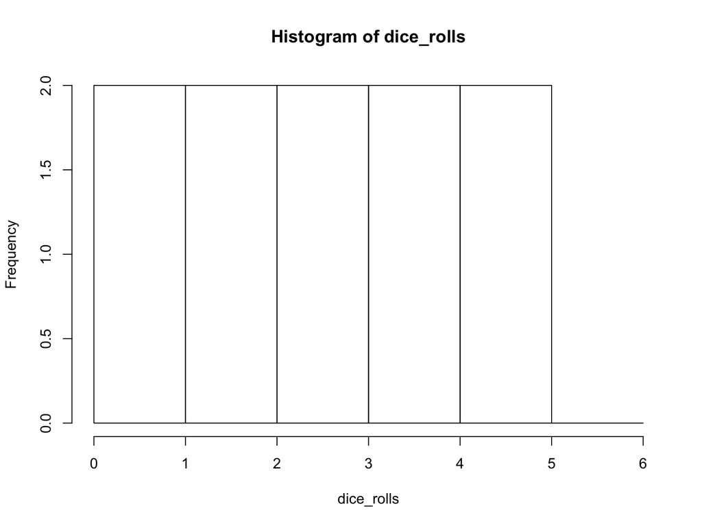

```r
hist(dice_rolls, breaks = 0:6)
```

## Rolling a dice for 100 times

```r
dice_rolls <- sample(dice, size = 100, replace = TRUE)
mean(dice_rolls)
```

```
## [1] 3.51
```

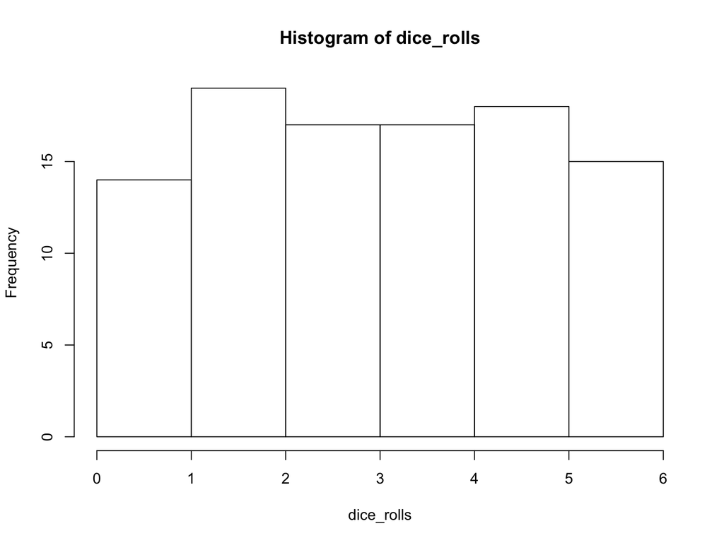

```r
hist(dice_rolls, breaks = 0:6)
```

```r
dice_rolls <- sample(dice, size = 100, replace = TRUE)
mean(dice_rolls)
```

```
## [1] 3.42
```

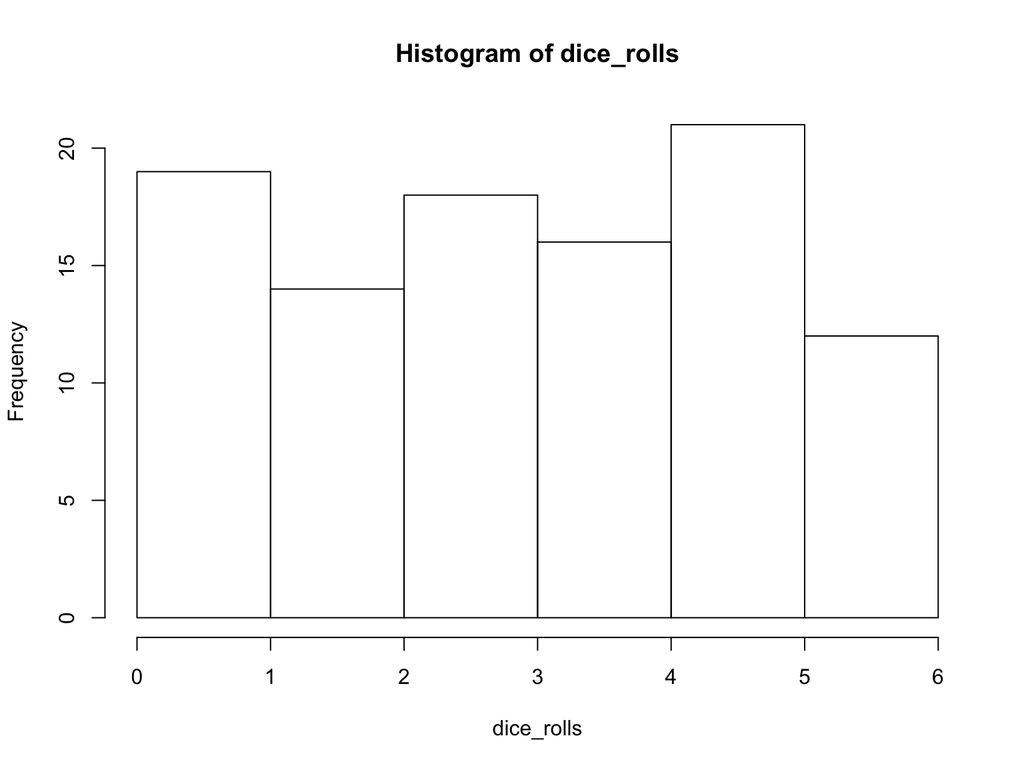

```r
hist(dice_rolls, breaks = 0:6)
```

# Probability rules

## Probability of intersection

$$P(A \; and \; B) = P(A) \times P(B)$$

## We can use operator `&` for intersection

```r
coin_A <- rbinom(n = 10000, size = 1, prob = 0.5)
coin_B <- rbinom(n = 10000, size = 1, prob = 0.5)
mean(coin_A == 1 & coin_B == 1) # Both coin_A and coin_B are heads
```

```
## [1] 0.246
```

```r
0.5 * 0.5
```

```
## [1] 0.25
```

## Probability of union

$$P(A \; or \; B) = P(A) + P(B) - P(A \; and \; B)$$

## We can use operator `|` for union

```r
coin_A <- rbinom(n = 10000, size = 1, prob = 0.5)
coin_B <- rbinom(n = 10000, size = 1, prob = 0.5)
mean(coin_A == 1 | coin_B == 1) # coin_A is head or coin_B is head
```

```
## [1] 0.7612
```

```r
(0.5 + 0.5) - 0.5*0.5
```

```
## [1] 0.75
```

## Flipping 3 coins

$$P(A \; and \; B \; and \; C) = P(A) \times P(B) \times P(C)$$

```r
# intersection
coin_A <- rbinom(n = 10000, size = 1, prob = 0.5)
coin_B <- rbinom(n = 10000, size = 1, prob = 0.5)
coin_C <- rbinom(n = 10000, size = 1, prob = 0.5)
mean(coin_A == 1 & coin_B == 1 & coin_C == 1)
```

```
## [1] 0.124
```

```r
0.5**3
```

```
## [1] 0.125
```

$$P(A \; or \; B \; or \; C) = P(A) + P(B) + P(C) - \\
(P(A) \times P(B) + P(A) \times P(C) + P(B) \times P(C)) + \\
P(A) \times P(B) \times P(C)$$

```r
# union
coin_A <- rbinom(n = 10000, size = 1, prob = 0.5)
coin_B <- rbinom(n = 10000, size = 1, prob = 0.5)
coin_C <- rbinom(n = 10000, size = 1, prob = 0.5)
mean(coin_A == 1 | coin_B == 1 | coin_C == 1)
```

```
## [1] 0.8705
```

```r
(0.5 + 0.5 + 0.5) - (0.5**2 + 0.5**2 + 0.5**2) + 0.5**3
```

```
## [1] 0.875
```

# The birthday problem

## What is the birthday problem

> There is a room(classroom?) with n people in it. What is the probability that anyone shares the same birthday?

## Assumptions of the birthday problem

- Ignore February 29th
- Each individual in the room is independent

## Using `sample()` to draw 40 samples from `1:365`

```r
dates_in_a_year <- format(as.Date(1:365, origin = "2019-01-01"), "%m-%d")
birthdays_num <- sample(1:365, size = 40, replace = TRUE)
birthdays <- dates_in_a_year[birthdays_num]
birthdays
```

```
##  [1] "02-08" "11-25" "07-20" "06-01" "10-16" "03-19" "04-19" "12-08" "10-24"
## [10] "08-21" "04-22" "03-13" "07-02" "07-14" "10-13" "11-24" "01-15" "05-05"
## [19] "02-08" "04-09" "12-12" "09-08" "01-05" "01-17" "01-18" "06-05" "10-05"
## [28] "11-17" "05-19" "12-18" "12-18" "04-11" "09-28" "02-13" "09-08" "12-16"
## [37] "01-06" "03-24" "08-12" "04-27"
```

## Extending the sampling to 10000 times

```r
counter <- 0
for (i in 1:10000) {
  birthdays_num <- sample(1:365, size = 40, replace = TRUE)
  if (length(unique(birthdays_num)) < length(birthdays_num)) {
    counter <- counter + 1
  }
}
p_same_birthday <- counter / 10000
p_same_birthday
```

```
## [1] 0.894
```

## Defining a `p_same_birthday(n)` function which takes a single argument `n`

```r
p_same_birthday <- function(n, n_simulations = 10000) {
  counter <- 0
  for (i in 1:n_simulations) {
    birthdays_num <- sample(1:365, size = n, replace = TRUE)
    unique_birthdays_num <- unique(birthdays_num)
    if (length(unique_birthdays_num) < length(birthdays_num)) {
      counter <- counter + 1
    }
  }
  p_same_birthday <- counter / n_simulations
  return(p_same_birthday)
}
```

## Simulating 50 classrooms with 1 to 50 students

```r
same_birthday_probs <- sapply(1:50, p_same_birthday)
same_birthday_probs
```

```
##  [1] 0.0000 0.0029 0.0085 0.0158 0.0247 0.0402 0.0556 0.0736 0.0924 0.1173
## [11] 0.1345 0.1675 0.1919 0.2219 0.2553 0.2858 0.3160 0.3546 0.3808 0.4140
## [21] 0.4438 0.4634 0.5061 0.5403 0.5817 0.6036 0.6217 0.6611 0.6795 0.7082
## [31] 0.7295 0.7530 0.7764 0.7928 0.8185 0.8299 0.8521 0.8616 0.8719 0.8905
## [41] 0.8999 0.9119 0.9238 0.9336 0.9444 0.9500 0.9563 0.9590 0.9665 0.9697
```

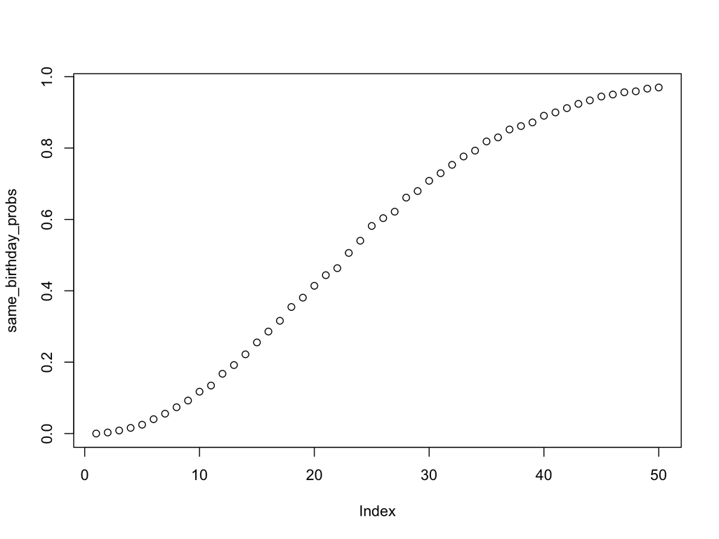

```r
plot(same_birthday_probs)
```

# The Monty Hall problem

## [21](https://www.imdb.com/title/tt0478087/)

[figure not shown]

## Contestant randomly pick 1 from 3 doors

```r
initial_pick <- sample(1:3, size = 1)
initial_pick
```

```
## [1] 2
```

## Monty Hall will then reveal an empty door

Ask the contestant, “stick or switch?”

## Simulating the winning probability of “stick”

```r
winning_prob_stick <- function(n_simulations = 10000) {
  doors <- c(1,2,3)
  n_wins <- 0
  for(i in 1:n_simulations){
    prize <- sample(doors, size = 1)
    initial_pick <- sample(doors, size = 1)
    if(initial_pick == prize){
      n_wins <- n_wins + 1
    }
  }
  winning_prob <- n_wins / n_simulations
  return(winning_prob)
}
```

```r
winning_prob_stick()
```

```
## [1] 0.3325
```

## The “reveal strategy” of Monty Hall

- If the initially pick is correct, then Monty Hall will choose one of the other two doors at random to reveal
- If the initially pick is incorrect, then the host will simply reveal the other incorrect door, nothing random at this point

```r
reveal_strategy <- function(doors, prize, initial_pick){
  if (prize == initial_pick) {
    reveal <- sample(x = doors[-prize], size = 1) # Sample at random from the two remaining doors
  } else {
    reveal <- doors[-c(prize, initial_pick)] # When the prize and initial pick are different, reveal the remaining door
  }
  return(reveal)
}
```

## Simulating the winning probability of “switch”

```r
winning_prob_switch <- function(n_simulations = 10000) {
  doors <- c(1,2,3)
  n_wins <- 0
  for(i in 1:n_simulations){
    prize <- sample(doors, size = 1)
    initial_pick <- sample(doors, size = 1)
    reveal <- reveal_strategy(doors, prize, initial_pick) # reveal according to reveal_strategy
    final_pick <- doors[c(-initial_pick, -reveal)] # switch
    if (final_pick == prize) {
      n_wins <- n_wins + 1
    }
  }
  winning_prob <- n_wins / n_simulations
  return(winning_prob)
}
```

```r
winning_prob_switch()
```

```
## [1] 0.6729
```